# SF Fire Analysis

The following is my notebook for approaching these problem. It is set up in a way that it can be easily shared and produce reproducible results. Under normal circumstances, I would make a client ready version that I would export as an HTML or PDF without code. If time permits, I’ll include that as well.

## Questions/Tasks

Task 1) There are perceived trends that tend to occur effecting turnout performance. Your task is to explore the validity of each trend. For each trend, present analysis in the form of visualization (chart, table, etc).

Task 2) are there additional trends that would be helpful for the department to know? You may use additional data sources if interest

## Loading the data

The first issue is getting the data into a manageable size for analysis. The whole data set is far too large to handle on my laptop, so I’ll work with the 2016 calls only. This file is itself 315.3 MB which is too large for me to handle effectively on my laptop. Therefore, I’m going to take a sample of rows from this file. This will provide some intuition regarding the questions that we can then explore in an environment better suited for handling such a large data set. Furthermore, conducting analysis on a sample before testing on the the larger body of data is a better way to ensure unbiased results and make sure we don’t find patterns in the data that don’t actually exist.

With that in mind, I’m going to read in the first 10,000 rows of data and perform the preliminary analysis on this subset. I’ll also write this out as a CSV to post on github and use for the remainder of the analysis.

```r
library(tidyverse) # R data science package

# This is the original code I used to read in a sample of the data set.  I'm keeping it here for reproducibility.
#
# sample_data <- read_csv("Fire_Department_Calls_For_Service__2016_.csv",
#                         n_max = 10000)
#
# write_csv(sample_data, "fire_subset.csv")

sample_data <- read_csv("fire_subset.csv") # this writes the actual file
```

Before moving on, I want to mention some issues inherent with taking the first 10,000 rows as my sample. This will only reflect data from midnight on January 1st through 2 PM on January 12th. I don’t know if this is a particularly busy or slow time (I would think that new years there may be a particularly busy time; conversely there may be fewer fires in the winter). Under normal circumstances, I would either select rows at random or better yet, work with the client to determine a time-frame that they feel is most appropriate.

## Evening Incidents

### Exploring and Cleaning

Let’s explore the data.

```r
glimpse(sample_data)
```

```
## Observations: 10,000
## Variables: 33
## $ `Call Number`                          <int> 160014033, 160014033, 1...
## $ `Unit ID`                              <chr> "E43", "85", "E17", "62...
## $ `Incident Number`                      <int> 16000555, 16000555, 160...
## $ `Call Date`                            <chr> "01/01/2016", "01/01/20...
## $ `Watch Date`                           <chr> "01/01/2016", "01/01/20...
## $ `Received DtTm`                        <chr> "01/01/2016 11:50:23 PM...
## $ `Entry DtTm`                           <chr> "01/01/2016 11:54:15 PM...
## $ `Dispatch DtTm`                        <chr> "01/01/2016 11:54:45 PM...
## $ `Response DtTm`                        <chr> "01/01/2016 11:56:23 PM...
## $ `On Scene DtTm`                        <chr> "01/01/2016 11:58:21 PM...
## $ `Transport DtTm`                       <chr> NA, "01/02/2016 12:20:2...
## $ `Hospital DtTm`                        <chr> NA, "01/02/2016 12:31:5...
## $ `Call Final Disposition`               <chr> "Code 2 Transport", "Co...
```

[output cut: 20 more lines]

For the first task, we’re interested in turnout time (**the duration of time between when a unit is dispatched and when the unit is en route**) at night. So let’s select the appropriate columns and then filter for night. I’m going to assume that `Dispatch DtTm` is the time that the unit is dispatched and that `Response DtTm` is the time they are en route (under normal circumstances I would confirm this with the client.)

```r
library(lubridate) # for dealing with dates and time

data_night <- sample_data %>%
  select(RowID, `Call Number`, `Dispatch DtTm`, `Response DtTm`) %>%  # select colums
  filter(!is.na(`Response DtTm`) == T) %>%  # filter out NA
  mutate(`Dispatch DtTm` = mdy_hms(`Dispatch DtTm`),
         `Response DtTm` = mdy_hms(`Response DtTm`)) %>% # change columns to mdy_hms format from character
  mutate(difference = `Response DtTm` - `Dispatch DtTm`) %>% # make a column with the difference
  mutate(just_time = hms(format(ymd_hms(`Dispatch DtTm`), "%H:%M:%S"))) %>% # make column with just the time
  mutate(night_day = if_else(just_time >= hms("20:00:00") | just_time <= hms("06:00:00"), # mark as day or night
                     "night",
                     "day"))

data_night
```

| RowID | Call Number | Dispatch DtTm | Response DtTm | difference | just_time | night_day |
| --- | --- | --- | --- | --- | --- | --- |
| 160014033-E43 | 160014033 | 2016-01-01 23:54:45 | 2016-01-01 23:56:23 | 98 secs | 23H 54M 45S | night |
| 160014033-85 | 160014033 | 2016-01-01 23:54:45 | 2016-01-01 23:54:57 | 12 secs | 23H 54M 45S | night |
| 160014027-E17 | 160014027 | 2016-01-01 23:52:03 | 2016-01-01 23:53:40 | 97 secs | 23H 52M 3S | night |
| 160014027-62 | 160014027 | 2016-01-01 23:52:03 | 2016-01-01 23:52:14 | 11 secs | 23H 52M 3S | night |
| 160014024-E23 | 160014024 | 2016-01-01 23:51:22 | 2016-01-01 23:52:58 | 96 secs | 23H 51M 22S | night |
| 160014001-79 | 160014001 | 2016-01-01 23:42:28 | 2016-01-01 23:42:35 | 7 secs | 23H 42M 28S | night |
| 160013993-60 | 160013993 | 2016-01-01 23:41:02 | 2016-01-01 23:41:10 | 8 secs | 23H 41M 2S | night |
| 160013992-E01 | 160013992 | 2016-01-01 23:40:39 | 2016-01-01 23:40:39 | 0 secs | 23H 40M 39S | night |
| 160013992-89 | 160013992 | 2016-01-01 23:39:35 | 2016-01-01 23:39:42 | 7 secs | 23H 39M 35S | night |
| 160013962-T03 | 160013962 | 2016-01-01 23:29:36 | 2016-01-01 23:30:24 | 48 secs | 23H 29M 36S | night |

[output cut: 9719 more lines]

Before Visualizing, let’s see on average if night response time are greater.

```r
data_night %>%
  group_by(night_day) %>%
  summarise(average = mean(difference), median = median(difference))
```

| night_day | average | median |
| --- | --- | --- |
| day | 62.33814 secs | 52 secs |
| night | 73.10051 secs | 64 secs |

So on average night does have a higher response time (both mean and median), but let’s see if that holds up when we analyze it visually.

### Visualize

Now let’s visualize the results.

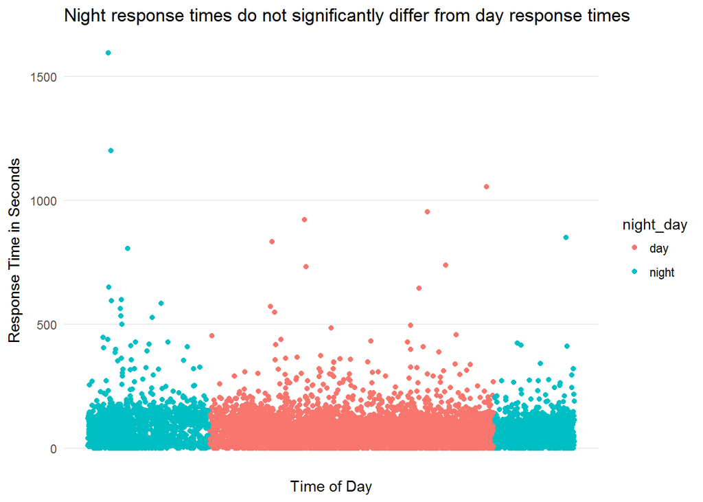

```r
ggplot(data_night, aes(x = as.numeric(just_time),
                       y = difference,
                       color = night_day)) +
  geom_point() +
  labs(y = "Response Time in Seconds",
       x = "Time of Day",
       title = "Night response times do not significantly differ from day response times") +
  theme_minimal() +
  theme(panel.grid.major.x = element_blank(),
        panel.grid.minor.x = element_blank(),
        panel.grid.minor.y = element_blank(),
        axis.text.x = element_blank())
```

### Interpret

In a full analysis, the next steps would be to perform some statistical testing to see if this difference is actually statistically significant.

## Back to Back Responses

For the second task, we’re interested in back to back response times (**back to back response is defined by a unit being dispatched within 10 minutes of becoming available**). So let’s select the appropriate columns and then filter for night. We’ll again use `Dispatch DtTm` as the time that the unit is dispatched and `Response DtTm` as the time they are en route (under normal circumstances I would confirm this with the client.) We’ll use `Available DtTm` for the time they became available.

In the following code I will:

- Select the appropriate variables
- Filter out NA responses
- Convert the date/time columns from character strings to date_time
- Add a column indicating whether the call was within 10 minutes of becoming available.

### Exploring and Cleaning

```r
data_available <- sample_data %>%
  select(RowID, `Call Number`, `Dispatch DtTm`, `Response DtTm`, `Available DtTm`) %>%  # select colums
  filter(!is.na(`Response DtTm`) == T,
         !is.na(`Available DtTm`) == T) %>%  # filter out NA
  mutate(`Dispatch DtTm` = mdy_hms(`Dispatch DtTm`),
         `Response DtTm` = mdy_hms(`Response DtTm`),
         `Available DtTm` = mdy_hms(`Available DtTm`)) %>% # change columns to mdy_hms format from character
  mutate(difference = `Response DtTm` - `Dispatch DtTm`) %>% # make a column with the difference
  mutate(diff_avail = `Available DtTm` - `Dispatch DtTm`) %>%
  mutate(back_to_back = if_else(diff_avail <= time_length(600),
                     "Yes",
                     "No"))

data_available
```

| RowID | Call Number | Dispatch DtTm | Response DtTm | Available DtTm | difference | diff_avail | back_to_back |
| --- | --- | --- | --- | --- | --- | --- | --- |
| 160014033-E43 | 160014033 | 2016-01-01 23:54:45 | 2016-01-01 23:56:23 | 2016-01-02 00:07:56 | 98 secs | 791 secs | No |
| 160014033-85 | 160014033 | 2016-01-01 23:54:45 | 2016-01-01 23:54:57 | 2016-01-02 01:04:10 | 12 secs | 4165 secs | No |
| 160014027-E17 | 160014027 | 2016-01-01 23:52:03 | 2016-01-01 23:53:40 | 2016-01-02 00:04:50 | 97 secs | 767 secs | No |
| 160014027-62 | 160014027 | 2016-01-01 23:52:03 | 2016-01-01 23:52:14 | 2016-01-02 01:17:15 | 11 secs | 5112 secs | No |
| 160014024-E23 | 160014024 | 2016-01-01 23:51:22 | 2016-01-01 23:52:58 | 2016-01-01 23:58:09 | 96 secs | 407 secs | Yes |
| 160014001-79 | 160014001 | 2016-01-01 23:42:28 | 2016-01-01 23:42:35 | 2016-01-01 23:54:34 | 7 secs | 726 secs | No |
| 160013993-60 | 160013993 | 2016-01-01 23:41:02 | 2016-01-01 23:41:10 | 2016-01-01 23:49:14 | 8 secs | 492 secs | Yes |
| 160013992-E01 | 160013992 | 2016-01-01 23:40:39 | 2016-01-01 23:40:39 | 2016-01-01 23:49:19 | 0 secs | 520 secs | Yes |
| 160013992-89 | 160013992 | 2016-01-01 23:39:35 | 2016-01-01 23:39:42 | 2016-01-02 00:50:51 | 7 secs | 4276 secs | No |
| 160013962-T03 | 160013962 | 2016-01-01 23:29:36 | 2016-01-01 23:30:24 | 2016-01-01 23:41:29 | 48 secs | 713 secs | No |

[output cut: 9718 more lines]

Before Visualizing, let’s see on average if night response time are greater.

```r
data_available %>%
  group_by(back_to_back) %>%
  summarise(average = mean(difference), median = median(difference))
```

| back_to_back | average | median |
| --- | --- | --- |
| No | 63.24933 secs | 47 secs |
| Yes | 72.40766 secs | 70 secs |

As with the night response time, back to back response times also appear to have higher mean and median responses. Let’s see if visualizing the results give us additional insight.

Visualize

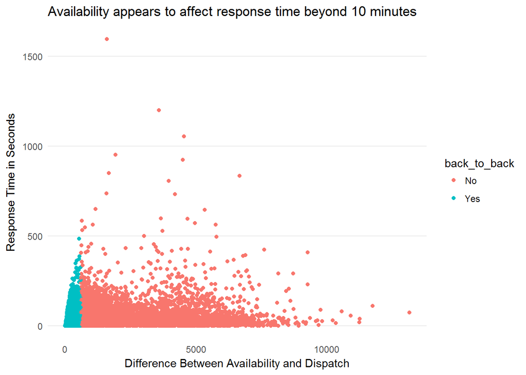

```r
ggplot(data_available, aes(x = as.numeric(diff_avail),
                       y = difference,
                       color = back_to_back)) +
  geom_point() +
  labs(y = "Response Time in Seconds",
       x = "Difference Between Availability and Dispatch",
       title = "Availability appears to affect response time beyond 10 minutes") +
  theme_minimal() +
  theme(panel.grid.major.x = element_blank(),
        panel.grid.minor.x = element_blank(),
        panel.grid.minor.y = element_blank())
```

### Intepret

In a full analysis, the next steps would be to perform some statistical testing to see if this difference is actually statistically significant.

## Additional Analysis

One additional analysis would be to analyze the results by neighborhood. This could be useful to see if certain areas are being served better than others.

```r
data_neighborhood <- sample_data %>%
  select(RowID, `Dispatch DtTm`, `Response DtTm`, `Neighborhooods - Analysis Boundaries`) %>%  # select colums
  filter(!is.na(`Response DtTm`) == T,
         !is.na(`Neighborhooods - Analysis Boundaries`)) %>%  # filter out NA
  mutate(`Dispatch DtTm` = mdy_hms(`Dispatch DtTm`),
         `Response DtTm` = mdy_hms(`Response DtTm`)) %>% # change columns to mdy_hms format from character
  mutate(difference = `Response DtTm` - `Dispatch DtTm`) %>% # make a column with the difference
  mutate(just_time = hms(format(ymd_hms(`Dispatch DtTm`), "%H:%M:%S"))) %>% # make column with just the time
  group_by(`Neighborhooods - Analysis Boundaries`) %>%
  summarise(average = mean(difference)) %>%
  ungroup() %>%
  arrange(desc(average)) %>%
  rename(Neighborhood = `Neighborhooods - Analysis Boundaries`)

data_neighborhood
```

| Neighborhood | average |
| --- | --- |
| Presidio | 103.50000 secs |
| Treasure Island | 91.12000 secs |
| Lakeshore | 80.28037 secs |
| Noe Valley | 78.73203 secs |
| Sunset/Parkside | 77.86740 secs |
| Bernal Heights | 77.75497 secs |
| Hayes Valley | 77.74725 secs |
| Visitacion Valley | 75.03158 secs |
| Oceanview/Merced/Ingleside | 74.85981 secs |
| Seacliff | 72.41667 secs |

[output cut: 32 more lines]

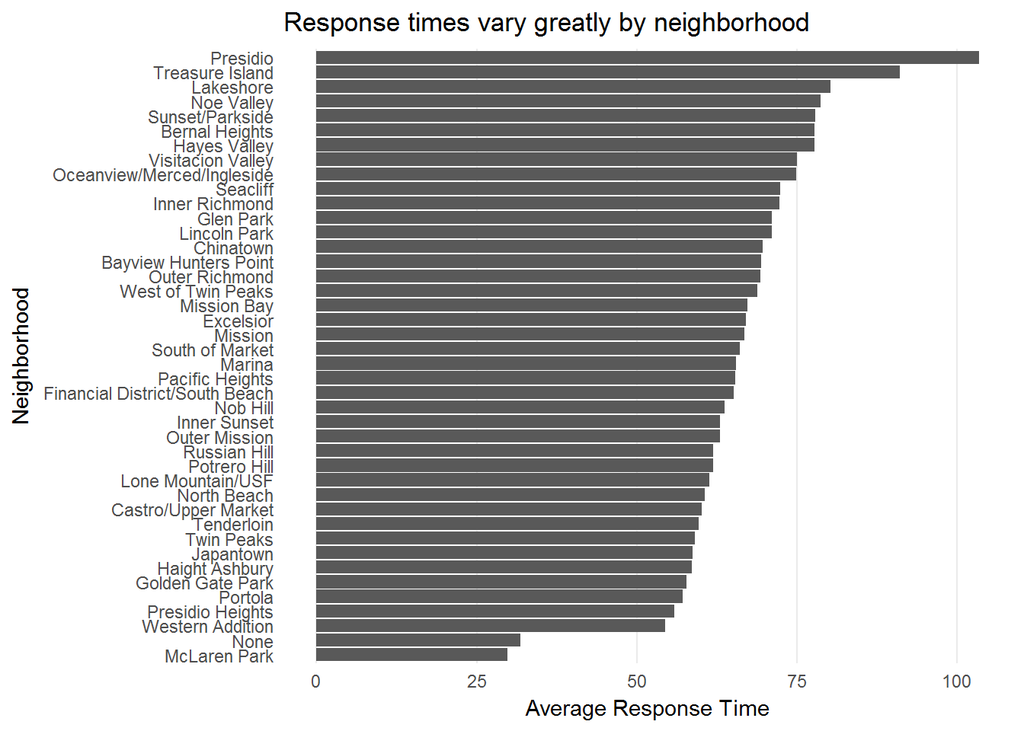

```r
ggplot(data_neighborhood, aes(x = reorder(Neighborhood, average), y = average)) +
  geom_col()+
  coord_flip() +
  labs(x = "Neighborhood",
       y = "Average Response Time",
       title = "Response times vary greatly by neighborhood") +
  theme_minimal() +
  theme(panel.grid.minor.x = element_blank(),
        panel.grid.major.y = element_blank(),
        panel.grid.minor.y = element_blank())
```

A subsequent phase of analysis would be to overlay this information on a map with other geospatial data like the location of fire stations and demographic data (socioeconomic, ethnic, etc.).